💻

# Lecture 2: Dataframes and plot

| Dates | @October 7, 2021 |
| --- | --- |
| Type | 📒 Lesson |
| Topic | Graphical RepresentationIntroduction to RMeasurements |
| Link | https://keats.kcl.ac.uk/mod/kalvidres/view.php?id=5688848 |

#### 📚 Recommended reading

| Name | Pages |
| --- | --- |
| ggplot2: Elegant Graphics for Data Analysis | 3-31 |

# Summary of session

- Dataframes
- How to install and load packages
- Tidyverse
- Intro to ggplot2
- Basic plots

# Review of concepts

## **Dataframes and plots**

```
Dep1 <- c(1:10)# comment 1
Dep2 <- c(11:20)# comment 2
Dependent <- cbind(Dep1, Dep2)# comment 3
```

```
install.packages("tidyverse")
library(tidyverse)
```

```
as_tibble(Dependent)
```

[output not shown]

1-10 of 10 rows

Then, we are going to download the file from Github. The nice thing about R is that we can enter all sorts of file types. We can use *read.csv()* to include data (e.g. data = read.csv(“locationoffile/file.csv”), or even SPSS data(!) through *read.spss(“”)*. But because it would take time for everyone to download a file and type it in, we are all going to directly download a file we put online, and read that in. So type in the following (or copy):

```
urlfile <- "https://raw.githubusercontent.com/HeJasonL/BIG-TAC/main/TutorialData.csv" # this loads a csv file called Tutorial Data and puts it into urlfile

tutorial_data <- read.csv(urlfile) # this reads the csv file that we put in urlfile and makes a new ‘dataframe’ called tutorial_data
```

So, two things to mention here. When we run data in R we typically use dataframes, which is a 2 dimensional data structure, similar to what we have in Excel, or SPSS (or Matlab). Secondly, with naming, there are certain conventions we won’t go into. By you cannot use spaces, some people prefer capitals, others don’t. Be consistent.

1. Looking at data. So the first thing we want to do, is view the data. We can do this by either double clicking on tutorial_data in the Environment screen, or by typing:

```
View(tutorial_data)
```

```
tutorial_data <- as_tibble(tutorial_data)
tutorial_data
```

[output not shown]

So here we have a data structure from a (fake) study in autism. We have 46 rows, each of which is an individual. We have 6 variables (columns). What are these data?

ID is participant IDs. Take them through this. Just categorical and continuous to keep it easy

Group is a ________________ variable indicating ASD or typically developing

Age is a ________________ variable indicating age of the participant

Sex is a ________________ variable indicating sex of the participants (M or F)

GABA is a ________________ variable indicating sensorimotor GABA levels

Sensory is a ________________ variable indicating sensory score on an arbitrary questionnaire

We can also immediately get descriptive data across the whole cohort, by using the summary function. But we run into one issue if we do this (try it):

```
summary(tutorial_data)
```

```
##     Sub_ID             Group                Age            Sex
##  Length:46          Length:46          Min.   :11.00   Length:46
##  Class :character   Class :character   1st Qu.:22.25   Class :character
##  Mode  :character   Mode  :character   Median :26.00   Mode  :character
##                                        Mean   :28.74
##                                        3rd Qu.:33.75
##                                        Max.   :55.00
##       GABA          Sensory1
##  Min.   :2.566   Min.   : 2.0
##  1st Qu.:4.654   1st Qu.:11.0
##  Median :4.907   Median :12.0
##  Mean   :5.138   Mean   :15.3
##  3rd Qu.:5.742   3rd Qu.:20.0
##  Max.   :7.890   Max.   :34.0
```

We see that both Group and Sex are shown as character strings rather than as categories (or in r, factors). This is due to the way we downloaded it. So we want to make these factors, so copy over the two lines below and run them. Here, the `$` sign allows us to get a specific column (variable) within our data frame. So *tutorial_data$Group* selects the Group column.

```
tutorial_data$Group <- as.factor(tutorial_data$Group)#makes Group a factor (ASD and TDC)
tutorial_data$Sex <- as.factor(tutorial_data$Sex)#makes Sex a factor (M and F)
```

```
tutorial_data
```

[output not shown]

We can then run *summary()* again and look at our descriptives!

```
summary(tutorial_data)
```

```
##     Sub_ID          Group         Age        Sex         GABA
##  Length:46          ASD:23   Min.   :11.00   F:14   Min.   :2.566
##  Class :character   TDC:23   1st Qu.:22.25   M:32   1st Qu.:4.654
##  Mode  :character            Median :26.00          Median :4.907
##                              Mean   :28.74          Mean   :5.138
##                              3rd Qu.:33.75          3rd Qu.:5.742
##                              Max.   :55.00          Max.   :7.890
##     Sensory1
##  Min.   : 2.0
##  1st Qu.:11.0
##  Median :12.0
##  Mean   :15.3
##  3rd Qu.:20.0
##  Max.   :34.0
```

How many women are in the study? 14 What is the mean GABA level across all participants? 5.138

Okay finally we are going to do some basic plotting. As discussed in the lecture, we are going to use ggplot to plot, which is a wonderful tool to build beautiful and informative plots. These are easy to amend and would take a whole 2-3 hour session to go through but let’s give it a go!

First, let’s do a quick histogram of values. This could be used to determine whether data are normally distributed (other ways, like levenes test, shapiro wilkes etc, also exist). So we are going to make a ggplot with *data = tutorial_data*.

In the aesthetics we are going to make the value of interest GABA, and we are going to separate it by group (*fill = Group*) and then we are going to make a histogram. To make it a little prettier, we make it a little transparent *(alpha = 0.6)* and we make the *binwidth = 0.5* but try different values and see how it affects the histogram!

```
ggplot(data = tutorial_data,
       aes(x=GABA,
           fill = Group)) +


  geom_histogram(alpha=0.6,
                 binwidth = 0.5)
```

[figure not shown]

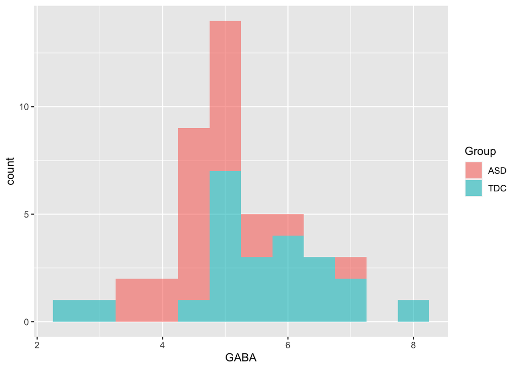

Next, we are going to make boxplots of sensory values by group.

```
ggplot(data = tutorial_data,
       aes(x = Group,
           y = Sensory1,
           fill = Group)) +

  geom_boxplot()
```

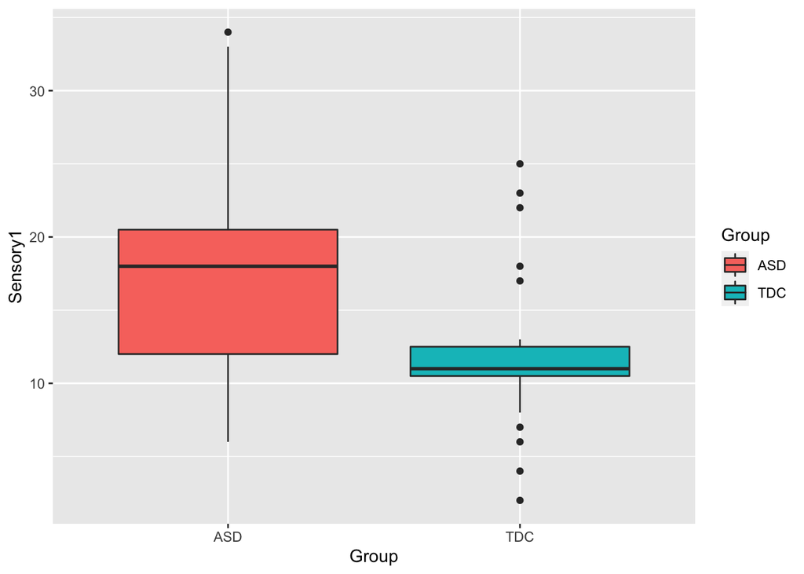

[figure not shown]

This looks nice, but how about we add some better labels and a title

```
ggplot(data = tutorial_data,
       aes(y = Sensory1,
           x = Group,
           fill = Group)) +
  geom_boxplot() +
  theme_bw() +
  xlab("Group") +
  ylab("Sensory Scores") +
  ggtitle("Sensory Scores by group") +
  theme(plot.title = element_text(hjust = 0.5))#align title centerd
```

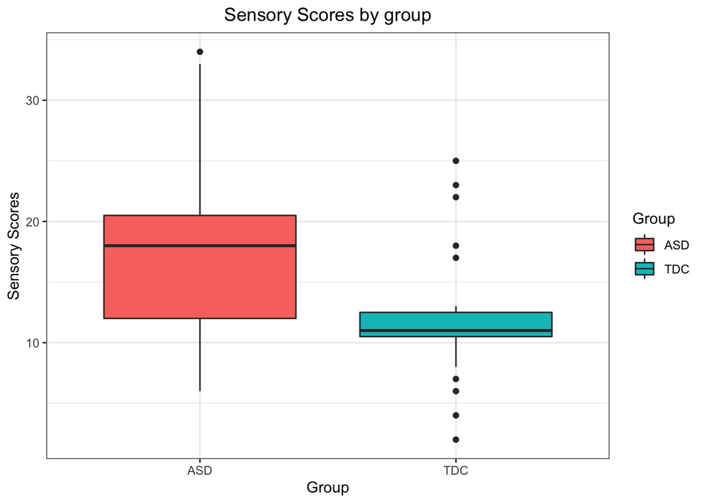

[figure not shown]

Here, we set a black and white theme (my preference) add x and y labels and a title, and center it.

```
ggplot(data = tutorial_data,
       aes(y = Sensory1,
           x = Group,
           fill = Group)) +
  geom_boxplot(outlier.shape = NA) +
  geom_point(aes(y = Sensory1),
             position=position_jitterdodge(jitter.width = 0.4,
                                           jitter.height = 0,
                                           dodge.width = 1)) +

  theme_bw() +
  xlab("Group") +
  ylab("Sensory Scores") +
  ggtitle("Sensory Scores by group") +
  theme(plot.title = element_text(hjust = 0.5))#align title centered
```

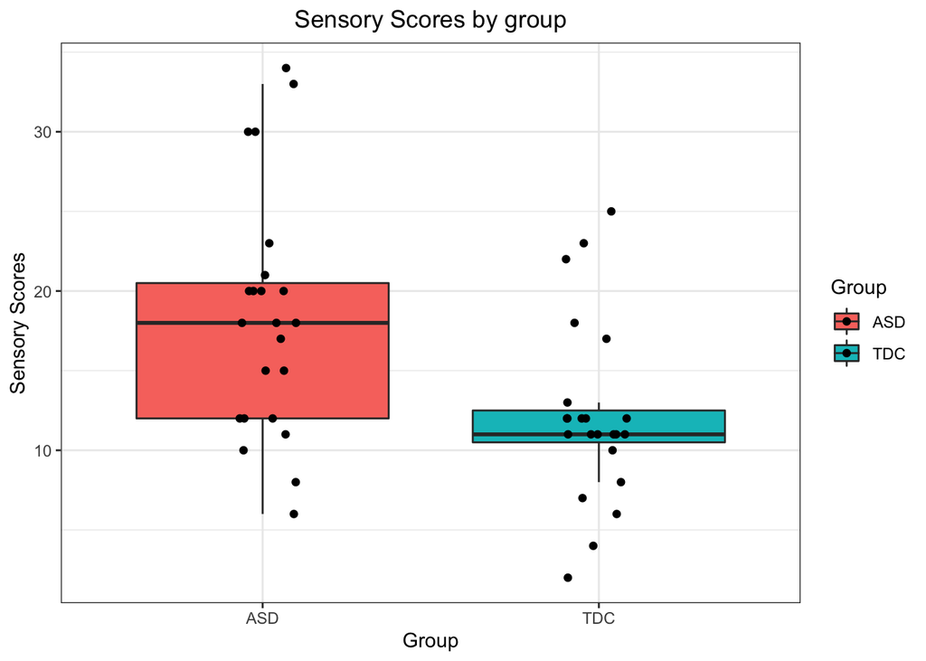

[figure not shown]

We can also color them by Sex if we want to, in *geom_point()* we can set color to *color = Sex*. We can also play around with *colors* more but we don’t have time for this today!